# Exploration des BD PASEC

```python
from IPython.display import display, HTML

# Masquer les codes en utilisant hide_input
display(HTML('<script>'
             'var code_show=true; '
             'function code_toggle() {'
             'if (code_show) {'
             '$(".input").hide();'
             '} else {'
             '$(".input").show();'
             '}'
             'code_show = !code_show'
             '}'
             '$( document ).ready(code_toggle);'
             '</script>'
             '<form action="javascript:code_toggle()"><input type="submit" value="afficher/masquer lecode ELAN-IFEF."></form>'))
```

[figure not shown]

[Cliquez ici pour accéder au site officiel de l'IFEF](https://ifef.francophonie.org/)

```python
from IPython.display import Image

# Charger l'image depuis un fichier local
image = Image(filename='LOGO_IFEF.jpg', width=200, height=200)

# Afficher l'image dans le notebook
display(image)

from IPython.display import HTML

# Créer un lien vers une page web
html_link = "<a href='https://ifef.francophonie.org/' target='_blank'>Cliquez ici pour accéder au site officiel de l'IFEF</a>"

# Afficher le lien dans le notebook
HTML(html_link)
```

EXPLORATION DES DONNEES

# Exploration des données de la 2é année des écoles bilingues en Côte d'Ivoire, en Guinée et au Togo

- Nombre d'observatons:**901**
- Nombre de variables :**315**
- Nombre d'eléves par pays: **RCI 378**, **Guinée 259**, Togo: **264**
- Nombre d'eléve par école: **variable d'une école à l'autre, entre 14 et 30**

**Visualisation des scores des eléves de 2A:** des nombreaux aléas identifiés, justifiant ainsi notre demande d'appronfondir l'analyse de la distribution des scores aussi bien en lecture et qu'en maths.

**En lecture:**

**En mathématiques:**

36 eléves (dont 24 du Togo, 7 de la Guinée et 5 de la Côte d'Ivoire) ont obtenu 0 en mathématiques, pourtant, 14 d'entre eux ont réalisés des scores en lecture variant entre 51,64 et 98,90 sur 100.

**Nous pensons que l traitement de ces individus qui sortent de l'ordinaire a eu un impact important sur les resultats finaux. Le Togo est de loin le pays le plus impacté par ces aléas (23 eléves en lecture et 24 en mathématique) et cela correlle potentiellement avec les scores trés faibles enregistrés dans ce pays.**

**Nombre d'eléves ayant réalisé un score de 100 points sur 100 en lecture:** 6 (dont 3 en RCI et 3 en Guinée)

**Nombre d'eléves ayant réaliser un score de 100 points sur 100 en mathématiques:** 49 (dont 31 en RCI, 12 en Guinée et 6 au Togo)

**Au regard de la visualisation, il existe une dependance positive modérée entre les performances en lecture et en mathéamtiques, c'est à dire que les eléves qui réalisent des bons scores en lectures ont globalement tendance à avoir des bons resultats en mathématiques. Nous presumons que la liaison aurait pu être forte sans les anomalies identifiées, tout comme les performances des eléves (le coefficient de pearson statistiquement significatif relevé entre les scores en lecture et en mathématiques est malgré tout de 0,50).**

Ces aléas restent importants aprés une standardisation et aprés une ACP

```python
import pandas as pd
import numpy as np
import matplotlib.pyplot as plt
import seaborn as sns
from sklearn.preprocessing import StandardScaler
from scipy.stats import pearsonr
from sklearn.decomposition import PCA
from sklearn.pipeline import Pipeline
```

```python
# importation des données
df2 = pd.read_excel('INTER_LIVRET_2A_ELAN.xlsx')
df5 = pd.read_excel('INTER_LIVRET_5A_ELAN.xlsx')
```

```python
df2.sample(5)
```

|  | ID_PAYS | numecole | numeleve | numadmin | l1a | l1b | l2001 | l2002 | l2003 | l2004 | ... | MAT26 | MAT27 | MAT28 | MAT29 | MAT30 | MAT31 | MAT32 | MAT33 | SCORE_FR2A100 | SCORE_MAT2A100 |
| --- | --- | --- | --- | --- | --- | --- | --- | --- | --- | --- | --- | --- | --- | --- | --- | --- | --- | --- | --- | --- | --- |
| 733 | 3 | 304 | 1 | 4 | 99.0 | 99.0 | 7.0 | 7.0 | 7.0 | 7.0 | ... | 0 | 1 | 1 | 1 | 1 | 1 | 1 | 1 | 0.000000 | 81.818184 |
| 170 | 1 | 107 | 7 | 9 | 3.0 | 0.0 | 1.0 | 1.0 | 1.0 | 1.0 | ... | 1 | 1 | 1 | 1 | 1 | 1 | 1 | 1 | 76.923080 | 87.878784 |
| 8 | 1 | 101 | 25 | 2 | 7.0 | 9.0 | 1.0 | 1.0 | 1.0 | 1.0 | ... | 0 | 1 | 1 | 1 | 1 | 1 | 1 | 1 | 89.010986 | 87.878784 |
| 835 | 3 | 308 | 22 | 8 | 6.0 | 7.0 | 1.0 | 1.0 | 1.0 | 1.0 | ... | 0 | 0 | 0 | 1 | 1 | 1 | 1 | 1 | 26.373627 | 42.424244 |
| 133 | 1 | 105 | 28 | 5 | 4.0 | 0.0 | 1.0 | 1.0 | 1.0 | 1.0 | ... | 1 | 1 | 1 | 1 | 1 | 1 | 1 | 1 | 63.736263 | 78.787880 |

5 rows × 315 columns

```python
df2.shape
```

```
(901, 315)
```

```python
df2.columns
```

```
Index(['ID_PAYS', 'numecole', 'numeleve', 'numadmin', 'l1a', 'l1b', 'l2001',
       'l2002', 'l2003', 'l2004',
       ...
       'MAT26', 'MAT27', 'MAT28', 'MAT29', 'MAT30', 'MAT31', 'MAT32', 'MAT33',
       'SCORE_FR2A100', 'SCORE_MAT2A100'],
      dtype='object', length=315)
```

```python
df2['ID_PAYS'].value_counts()
```

```
1    378
3    264
2    259
Name: ID_PAYS, dtype: int64
```

```python
df2['Pays'] = df2['ID_PAYS'].replace({1:'RCI', 2:'Guinée', 3:'Togo'})
```

```python
df2['Pays'].value_counts()
```

```
RCI       378
Togo      264
Guinée    259
Name: Pays, dtype: int64
```

```python
# nombre d'eléve par école d'un pays à l'autre
df2.groupby('Pays')['numecole'].value_counts()
```

```
Pays    numecole
Guinée  207         30
        208         30
        209         30
        210         30
        205         28
        203         26
        202         25
        201         22
        204         22
        206         16
RCI     101         30
        102         30
        105         30
        107         30
```

[output cut: 21 more lines]

```python
#Score moyen et écartype en lecture et en mathématiques par école, d'un pays à l'autre
df2.groupby(['Pays', 'numecole'])['SCORE_FR2A100', 'SCORE_MAT2A100'].agg(['mean', 'std'])
```

| Pays | numecole | SCORE_FR2A100 mean | SCORE_FR2A100 std | SCORE_MAT2A100 mean | SCORE_MAT2A100 std |
| --- | --- | --- | --- | --- | --- |
| Guinée | 201 | 67.732268 | 21.753287 | 75.344352 | 28.106471 |
|  | 202 | 53.098902 | 16.892723 | 56.969696 | 31.088309 |
|  | 203 | 48.520710 | 24.559772 | 61.072261 | 27.140316 |
|  | 204 | 58.541459 | 25.765226 | 57.851240 | 20.120523 |
|  | 205 | 61.577708 | 12.896971 | 57.900432 | 19.135825 |
|  | 206 | 68.818682 | 19.718565 | 81.250000 | 19.676563 |
|  | 207 | 61.245422 | 21.818163 | 64.040403 | 25.224784 |
|  | 208 | 67.106227 | 18.480595 | 58.787879 | 21.362358 |
|  | 209 | 70.293041 | 19.426511 | 73.434343 | 20.532219 |
|  | 210 | 42.600733 | 18.648263 | 44.242424 | 17.336680 |
| RCI | 101 | 88.131868 | 16.716554 | 89.999998 | 8.795262 |
|  | 102 | 73.076923 | 30.458768 | 93.030302 | 8.003593 |
|  | 103 | 59.643804 | 21.855815 | 70.950888 | 27.230815 |
|  | 104 | 52.547452 | 16.616025 | 75.482093 | 17.114132 |
|  | 105 | 61.428572 | 31.490689 | 67.272727 | 26.850322 |
|  | 106 | 47.682753 | 27.055252 | 66.666666 | 27.682866 |
|  | 107 | 51.282052 | 21.919843 | 82.222222 | 14.988323 |
|  | 108 | 63.406594 | 26.340687 | 59.292929 | 22.630352 |
|  | 109 | 57.525084 | 19.977946 | 67.457180 | 12.831053 |
|  | 110 | 46.805047 | 20.373054 | 61.728395 | 21.659423 |
|  | 111 | 76.080587 | 16.496605 | 78.282828 | 14.458187 |
|  | 112 | 58.791209 | 23.351816 | 75.454546 | 10.202038 |
|  | 113 | 72.527473 | 26.565552 | 71.717171 | 22.329622 |
|  | 114 | 59.105181 | 25.973217 | 54.761905 | 21.310603 |
| Togo | 301 | 54.029304 | 24.039513 | 65.151515 | 20.717475 |
|  | 302 | 47.752247 | 26.307537 | 51.928375 | 30.393738 |
|  | 303 | 41.978022 | 33.953495 | 65.696969 | 36.539139 |
|  | 304 | 66.758242 | 31.065245 | 76.298701 | 20.152356 |
|  | 305 | 41.077969 | 22.366015 | 41.991342 | 26.002149 |
|  | 306 | 70.805861 | 19.098355 | 69.191919 | 20.707283 |
|  | 307 | 43.543956 | 24.350695 | 35.858585 | 22.741175 |
|  | 308 | 38.992042 | 21.071616 | 47.648903 | 22.163225 |
|  | 309 | 45.447409 | 26.406190 | 68.614718 | 20.423271 |
|  | 310 | 37.647538 | 20.042853 | 52.188552 | 30.225230 |

```python
print(df2['Pays'].dtypes)
```

```
object
```

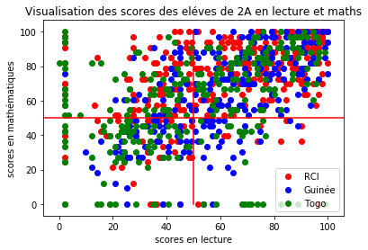

```python
categories = df2['Pays'].unique()
colors = ['red', 'blue', 'green']


fig = plt.figure()
for i, cat in enumerate(categories):
    x = df2[df2['Pays'] == cat]['SCORE_FR2A100']
    y = df2[df2['Pays'] == cat]['SCORE_MAT2A100']

    plt.scatter(x, y, c=colors[i], label=cat, alpha=1)


constant = 50
plt.axhline(constant, color='r', linestyle='-')
plt.plot([constant, constant], [0, 100], color='red')


plt.title('Visualisation des scores des eléves de 2A en lecture et maths')
plt.xlabel('scores en lecture')
plt.ylabel('scores en mathématiques')
plt.legend()
plt.show()

fig.savefig('ScoresDesEleves2AEnLecEtMath.png')
```

```python
#segmentation de la df2 selon les scores en lecture et mathématiques
df22 = df2[['Pays', 'numecole', 'numeleve',
            'SCORE_FR2A100', 'SCORE_MAT2A100']]
df_lectOut = df22[df22['SCORE_FR2A100'] < 5]
df_mathOut = df22[df22['SCORE_MAT2A100'] == 0]
```

```python
print("le nombre d'eléve ayant obtenu 0 ou le core constant 2.197802 en lecture est égal à:",
      df_lectOut.shape[0], "\nVoici le tableau de ces eléves:")
print(df_lectOut)
```

```
le nombre d'eléve ayant obtenu 0 ou le core constant 2.197802 en lecture est égal à: 38
Voici le tableau de ces eléves:
       Pays  numecole  numeleve  SCORE_FR2A100  SCORE_MAT2A100
32      RCI       102        11       2.197802       90.909088
35      RCI       102         7       2.197802       96.969696
42      RCI       102        30       2.197802       96.969696
53      RCI       102         5       2.197802       96.969696
116     RCI       105        13       2.197802       42.424244
123     RCI       105         6       2.197802       27.272728
141     RCI       106        21       2.197802       69.696968
154     RCI       106        12       2.197802       63.636364
157     RCI       106        19       2.197802       81.818184
160     RCI       106        15       2.197802       39.393940
213     RCI       108         5       2.197802       66.666664
217     RCI       108        20       2.197802       24.242424
```

[output cut: 26 more lines]

```python
# Statistique des eléves ayant fait l'objet d'aléas importants en lecture
df_lectOut.describe(include ='all')
```

|  | Pays | numecole | numeleve | SCORE_FR2A100 | SCORE_MAT2A100 |
| --- | --- | --- | --- | --- | --- |
| count | 38 | 38.000000 | 38.000000 | 38.000000 | 38.000000 |
| unique | 3 | NaN | NaN | NaN | NaN |
| top | Togo | NaN | NaN | NaN | NaN |
| freq | 23 | NaN | NaN | NaN | NaN |
| mean | NaN | 228.921053 | 15.289474 | 2.168884 | 62.121212 |
| std | NaN | 96.696343 | 8.529465 | 0.402900 | 27.247690 |
| min | NaN | 102.000000 | 1.000000 | 0.000000 | 0.000000 |
| 25% | NaN | 106.500000 | 8.000000 | 2.197802 | 42.424244 |
| 50% | NaN | 303.000000 | 15.000000 | 2.197802 | 63.636364 |
| 75% | NaN | 304.000000 | 21.000000 | 2.197802 | 81.818184 |
| max | NaN | 309.000000 | 30.000000 | 3.296703 | 100.000000 |

```python
df_lectOut['Pays'].value_counts()
```

```
Togo      23
RCI       14
Guinée     1
Name: Pays, dtype: int64
```

```python
print("le nombre d'eléve ayant obtenu 0 en mathématiques est égal à:",df_mathOut.shape[0], "\nVoici le tableau de ces eléves:")
print(df_mathOut)
```

```
le nombre d'eléve ayant obtenu 0 en mathématiques est égal à: 36
Voici le tableau de ces eléves:
       Pays  numecole  numeleve  SCORE_FR2A100  SCORE_MAT2A100
81      RCI       103         7      34.065933             0.0
82      RCI       103         4      36.263737             0.0
148     RCI       106        13      45.054947             0.0
163     RCI       106         3      96.703300             0.0
210     RCI       108         9      51.648350             0.0
395  Guinée       201        18      57.142857             0.0
404  Guinée       202        10      35.164837             0.0
411  Guinée       202         9      45.054947             0.0
417  Guinée       202        23      38.461540             0.0
424  Guinée       202        20      53.846153             0.0
431  Guinée       203         6      38.461540             0.0
447  Guinée       203        22      25.274725             0.0
```

[output cut: 24 more lines]

```python
# Statistique des eléves ayant fait l'objet d'aléas importants en mathématiques
df_mathOut.describe(include='all')
```

|  | Pays | numecole | numeleve | SCORE_FR2A100 | SCORE_MAT2A100 |
| --- | --- | --- | --- | --- | --- |
| count | 36 | 36.000000 | 36.000000 | 36.000000 | 36.0 |
| unique | 3 | NaN | NaN | NaN | NaN |
| top | Togo | NaN | NaN | NaN | NaN |
| freq | 24 | NaN | NaN | NaN | NaN |
| mean | NaN | 257.527778 | 15.555556 | 46.398047 | 0.0 |
| std | NaN | 74.209544 | 7.684658 | 25.351887 | 0.0 |
| min | NaN | 103.000000 | 3.000000 | 2.197802 | 0.0 |
| 25% | NaN | 202.000000 | 9.000000 | 32.692307 | 0.0 |
| 50% | NaN | 303.000000 | 17.500000 | 39.560440 | 0.0 |
| 75% | NaN | 307.000000 | 22.000000 | 68.406591 | 0.0 |
| max | NaN | 310.000000 | 30.000000 | 98.901100 | 0.0 |

```python
df_mathOut['Pays'].value_counts()
```

```
Togo      24
Guinée     7
RCI        5
Name: Pays, dtype: int64
```

```python
print("le nombre d'eléves ayant réalisé un score de 100 sur 100 en lecture est égal à:",
      df2[df2['SCORE_FR2A100'] == 100].shape[0])
print("le nombre d'eléves ayant réalisé un score de 100 sur 100 en mathématiques est égal à:",
      df2[df2['SCORE_MAT2A100'] == 100].shape[0])
```

```
le nombre d'eléves ayant réalisé un score de 100 sur 100 en lecture est égal à: 6
le nombre d'eléves ayant réalisé un score de 100 sur 100 en mathématiques est égal à: 49
```

```python
df2[df2['SCORE_FR2A100'] == 100]
```

|  | ID_PAYS | numecole | numeleve | numadmin | l1a | l1b | l2001 | l2002 | l2003 | l2004 | ... | MAT27 | MAT28 | MAT29 | MAT30 | MAT31 | MAT32 | MAT33 | SCORE_FR2A100 | SCORE_MAT2A100 | Pays |
| --- | --- | --- | --- | --- | --- | --- | --- | --- | --- | --- | --- | --- | --- | --- | --- | --- | --- | --- | --- | --- | --- |
| 3 | 1 | 101 | 3 | 2 | 7.0 | 3.0 | 1.0 | 1.0 | 1.0 | 1.0 | ... | 1 | 1 | 1 | 1 | 1 | 1 | 1 | 100.0 | 100.000000 | RCI |
| 12 | 1 | 101 | 14 | 2 | 7.0 | 3.0 | 1.0 | 1.0 | 1.0 | 1.0 | ... | 1 | 1 | 1 | 1 | 1 | 1 | 1 | 100.0 | 81.818184 | RCI |
| 50 | 1 | 102 | 21 | 14 | 7.0 | 30.0 | 1.0 | 1.0 | 1.0 | 1.0 | ... | 1 | 1 | 1 | 1 | 1 | 1 | 1 | 100.0 | 100.000000 | RCI |
| 530 | 2 | 207 | 12 | 7 | 7.0 | 40.0 | 1.0 | 1.0 | 1.0 | 1.0 | ... | 0 | 1 | 1 | 1 | 1 | 1 | 1 | 100.0 | 75.757576 | Guinée |
| 531 | 2 | 207 | 18 | 7 | 7.0 | 20.0 | 1.0 | 1.0 | 1.0 | 1.0 | ... | 1 | 1 | 1 | 1 | 1 | 1 | 1 | 100.0 | 93.939392 | Guinée |
| 593 | 2 | 209 | 9 | 9 | 7.0 | 17.0 | 1.0 | 1.0 | 1.0 | 1.0 | ... | 1 | 1 | 1 | 1 | 1 | 1 | 1 | 100.0 | 100.000000 | Guinée |

6 rows × 316 columns

```python
# Extraction des eléves ayant réaliser un score de 100 point sur 100 en mathématiques
df2[df2['SCORE_MAT2A100'] == 100]
```

|  | ID_PAYS | numecole | numeleve | numadmin | l1a | l1b | l2001 | l2002 | l2003 | l2004 | ... | MAT27 | MAT28 | MAT29 | MAT30 | MAT31 | MAT32 | MAT33 | SCORE_FR2A100 | SCORE_MAT2A100 | Pays |
| --- | --- | --- | --- | --- | --- | --- | --- | --- | --- | --- | --- | --- | --- | --- | --- | --- | --- | --- | --- | --- | --- |
| 3 | 1 | 101 | 3 | 2 | 7.0 | 3.0 | 1.0 | 1.0 | 1.0 | 1.0 | ... | 1 | 1 | 1 | 1 | 1 | 1 | 1 | 100.000000 | 100.0 | RCI |
| 37 | 1 | 102 | 24 | 14 | 7.0 | 6.0 | 1.0 | 1.0 | 1.0 | 1.0 | ... | 1 | 1 | 1 | 1 | 1 | 1 | 1 | 97.802200 | 100.0 | RCI |
| 40 | 1 | 102 | 10 | 14 | 6.0 | 3.0 | 1.0 | 1.0 | 1.0 | 1.0 | ... | 1 | 1 | 1 | 1 | 1 | 1 | 1 | 73.626373 | 100.0 | RCI |
| 41 | 1 | 102 | 25 | 14 | 8.0 | 5.0 | 1.0 | 1.0 | 1.0 | 1.0 | ... | 1 | 1 | 1 | 1 | 1 | 1 | 1 | 94.505493 | 100.0 | RCI |
| 44 | 1 | 102 | 2 | 14 | 8.0 | 35.0 | 1.0 | 1.0 | 1.0 | 1.0 | ... | 1 | 1 | 1 | 1 | 1 | 1 | 1 | 89.010986 | 100.0 | RCI |
| 46 | 1 | 102 | 6 | 14 | 6.0 | 0.0 | 1.0 | 1.0 | 1.0 | 1.0 | ... | 1 | 1 | 1 | 1 | 1 | 1 | 1 | 74.725273 | 100.0 | RCI |
| 47 | 1 | 102 | 3 | 14 | 4.0 | 12.0 | 1.0 | 1.0 | 1.0 | 1.0 | ... | 1 | 1 | 1 | 1 | 1 | 1 | 1 | 80.219780 | 100.0 | RCI |
| 50 | 1 | 102 | 21 | 14 | 7.0 | 30.0 | 1.0 | 1.0 | 1.0 | 1.0 | ... | 1 | 1 | 1 | 1 | 1 | 1 | 1 | 100.000000 | 100.0 | RCI |
| 52 | 1 | 102 | 29 | 14 | 8.0 | 33.0 | 1.0 | 1.0 | 1.0 | 1.0 | ... | 1 | 1 | 1 | 1 | 1 | 1 | 1 | 79.120880 | 100.0 | RCI |
| 55 | 1 | 102 | 28 | 14 | 8.0 | 21.0 | 1.0 | 1.0 | 1.0 | 1.0 | ... | 1 | 1 | 1 | 1 | 1 | 1 | 1 | 93.406593 | 100.0 | RCI |
| 57 | 1 | 102 | 18 | 14 | 8.0 | 41.0 | 1.0 | 1.0 | 1.0 | 1.0 | ... | 1 | 1 | 1 | 1 | 1 | 1 | 1 | 98.901100 | 100.0 | RCI |
| 59 | 1 | 102 | 9 | 14 | 8.0 | 40.0 | 1.0 | 1.0 | 1.0 | 1.0 | ... | 1 | 1 | 1 | 1 | 1 | 1 | 1 | 85.714287 | 100.0 | RCI |
| 65 | 1 | 103 | 9 | 13 | 8.0 | 1.0 | 1.0 | 1.0 | 1.0 | 1.0 | ... | 1 | 1 | 1 | 1 | 1 | 1 | 1 | 84.615387 | 100.0 | RCI |
| 69 | 1 | 103 | 23 | 13 | 7.0 | 0.0 | 1.0 | 1.0 | 1.0 | 1.0 | ... | 1 | 1 | 1 | 1 | 1 | 1 | 1 | 91.208794 | 100.0 | RCI |
| 79 | 1 | 103 | 13 | 13 | 8.0 | 7.0 | 1.0 | 1.0 | 1.0 | 1.0 | ... | 1 | 1 | 1 | 1 | 1 | 1 | 1 | 95.604393 | 100.0 | RCI |
| 83 | 1 | 103 | 28 | 13 | 8.0 | 21.0 | 1.0 | 1.0 | 1.0 | 1.0 | ... | 1 | 1 | 1 | 1 | 1 | 1 | 1 | 96.703300 | 100.0 | RCI |
| 90 | 1 | 104 | 7 | 7 | 8.0 | 0.0 | 1.0 | 1.0 | 1.0 | 1.0 | ... | 1 | 1 | 1 | 1 | 1 | 1 | 1 | 50.549450 | 100.0 | RCI |
| 91 | 1 | 104 | 2 | 7 | 8.0 | 30.0 | 7.0 | 7.0 | 7.0 | 7.0 | ... | 1 | 1 | 1 | 1 | 1 | 1 | 1 | 51.648350 | 100.0 | RCI |
| 126 | 1 | 105 | 9 | 5 | 7.0 | 0.0 | 1.0 | 1.0 | 1.0 | 1.0 | ... | 1 | 1 | 1 | 1 | 1 | 1 | 1 | 92.307693 | 100.0 | RCI |
| 131 | 1 | 105 | 3 | 5 | 8.0 | 19.0 | 1.0 | 1.0 | 1.0 | 1.0 | ... | 1 | 1 | 1 | 1 | 1 | 1 | 1 | 86.813187 | 100.0 | RCI |
| 139 | 1 | 105 | 20 | 5 | 8.0 | 43.0 | 1.0 | 1.0 | 1.0 | 1.0 | ... | 1 | 1 | 1 | 1 | 1 | 1 | 1 | 98.901100 | 100.0 | RCI |
| 162 | 1 | 106 | 11 | 8 | 6.0 | 0.0 | 1.0 | 1.0 | 2.0 | 1.0 | ... | 1 | 1 | 1 | 1 | 1 | 1 | 1 | 45.054947 | 100.0 | RCI |
| 180 | 1 | 107 | 2 | 9 | 7.0 | 10.0 | 1.0 | 1.0 | 1.0 | 1.0 | ... | 1 | 1 | 1 | 1 | 1 | 1 | 1 | 90.109894 | 100.0 | RCI |
| 189 | 1 | 107 | 17 | 9 | 8.0 | 22.0 | 1.0 | 1.0 | 2.0 | 1.0 | ... | 1 | 1 | 1 | 1 | 1 | 1 | 1 | 48.351650 | 100.0 | RCI |
| 197 | 1 | 108 | 30 | 10 | 8.0 | 20.0 | 7.0 | 7.0 | 7.0 | 7.0 | ... | 1 | 1 | 1 | 1 | 1 | 1 | 1 | 42.857143 | 100.0 | RCI |
| 249 | 1 | 110 | 25 | 1 | 6.0 | 0.0 | 1.0 | 1.0 | 1.0 | 1.0 | ... | 1 | 1 | 1 | 1 | 1 | 1 | 1 | 57.142857 | 100.0 | RCI |
| 250 | 1 | 110 | 4 | 1 | 8.0 | 5.0 | 1.0 | 1.0 | 1.0 | 1.0 | ... | 1 | 1 | 1 | 1 | 1 | 1 | 1 | 90.109894 | 100.0 | RCI |
| 263 | 1 | 110 | 20 | 1 | 8.0 | 20.0 | 1.0 | 1.0 | 1.0 | 1.0 | ... | 1 | 1 | 1 | 1 | 1 | 1 | 1 | 84.615387 | 100.0 | RCI |
| 336 | 1 | 113 | 2 | 6 | 8.0 | 26.0 | 1.0 | 1.0 | 1.0 | 1.0 | ... | 1 | 1 | 1 | 1 | 1 | 1 | 1 | 91.208794 | 100.0 | RCI |
| 348 | 1 | 113 | 15 | 6 | 8.0 | 18.0 | 1.0 | 1.0 | 1.0 | 1.0 | ... | 1 | 1 | 1 | 1 | 1 | 1 | 1 | 96.703300 | 100.0 | RCI |
| 356 | 1 | 113 | 9 | 6 | 8.0 | 0.0 | 1.0 | 1.0 | 1.0 | 1.0 | ... | 1 | 1 | 1 | 1 | 1 | 1 | 1 | 91.208794 | 100.0 | RCI |
| 381 | 2 | 201 | 5 | 1 | 7.0 | 51.0 | 1.0 | 1.0 | 1.0 | 1.0 | ... | 1 | 1 | 1 | 1 | 1 | 1 | 1 | 92.307693 | 100.0 | Guinée |
| 383 | 2 | 201 | 3 | 1 | 7.0 | 51.0 | 1.0 | 1.0 | 1.0 | 1.0 | ... | 1 | 1 | 1 | 1 | 1 | 1 | 1 | 79.120880 | 100.0 | Guinée |
| 392 | 2 | 201 | 19 | 1 | 7.0 | 18.0 | 1.0 | 1.0 | 1.0 | 2.0 | ... | 1 | 1 | 1 | 1 | 1 | 1 | 1 | 50.549450 | 100.0 | Guinée |
| 393 | 2 | 201 | 4 | 1 | 7.0 | 40.0 | 1.0 | 1.0 | 1.0 | 1.0 | ... | 1 | 1 | 1 | 1 | 1 | 1 | 1 | 89.010986 | 100.0 | Guinée |
| 444 | 2 | 203 | 11 | 3 | 6.0 | 22.0 | 1.0 | 1.0 | 1.0 | 1.0 | ... | 1 | 1 | 1 | 1 | 1 | 1 | 1 | 75.824173 | 100.0 | Guinée |
| 510 | 2 | 206 | 1 | 6 | 7.0 | 10.0 | 1.0 | 1.0 | 1.0 | 1.0 | ... | 1 | 1 | 1 | 1 | 1 | 1 | 1 | 84.615387 | 100.0 | Guinée |
| 513 | 2 | 206 | 10 | 6 | 0.0 | 0.0 | 1.0 | 1.0 | 1.0 | 1.0 | ... | 1 | 1 | 1 | 1 | 1 | 1 | 1 | 75.824173 | 100.0 | Guinée |
| 523 | 2 | 207 | 8 | 7 | 7.0 | 20.0 | 1.0 | 1.0 | 1.0 | 2.0 | ... | 1 | 1 | 1 | 1 | 1 | 1 | 1 | 64.835167 | 100.0 | Guinée |
| 578 | 2 | 209 | 17 | 9 | 7.0 | 45.0 | 1.0 | 1.0 | 1.0 | 1.0 | ... | 1 | 1 | 1 | 1 | 1 | 1 | 1 | 71.428574 | 100.0 | Guinée |
| 589 | 2 | 209 | 23 | 9 | 7.0 | 20.0 | 1.0 | 1.0 | 1.0 | 1.0 | ... | 1 | 1 | 1 | 1 | 1 | 1 | 1 | 97.802200 | 100.0 | Guinée |
| 590 | 2 | 209 | 5 | 9 | 7.0 | 45.0 | 1.0 | 1.0 | 1.0 | 1.0 | ... | 1 | 1 | 1 | 1 | 1 | 1 | 1 | 95.604393 | 100.0 | Guinée |
| 593 | 2 | 209 | 9 | 9 | 7.0 | 17.0 | 1.0 | 1.0 | 1.0 | 1.0 | ... | 1 | 1 | 1 | 1 | 1 | 1 | 1 | 100.000000 | 100.0 | Guinée |
| 690 | 3 | 303 | 20 | 3 | 9.0 | 99.0 | 9.0 | 9.0 | 9.0 | 9.0 | ... | 1 | 1 | 1 | 1 | 1 | 1 | 1 | 2.197802 | 100.0 | Togo |
| 697 | 3 | 303 | 13 | 3 | 9.0 | 99.0 | 1.0 | 1.0 | 1.0 | 1.0 | ... | 1 | 1 | 1 | 1 | 1 | 1 | 1 | 82.417580 | 100.0 | Togo |
| 710 | 3 | 303 | 1 | 3 | 8.0 | 24.0 | 1.0 | 1.0 | 1.0 | 1.0 | ... | 1 | 1 | 1 | 1 | 1 | 1 | 1 | 91.208794 | 100.0 | Togo |
| 714 | 3 | 304 | 12 | 4 | 8.0 | 8.0 | 1.0 | 1.0 | 1.0 | 1.0 | ... | 1 | 1 | 1 | 1 | 1 | 1 | 1 | 94.505493 | 100.0 | Togo |
| 720 | 3 | 304 | 2 | 4 | 4.0 | 2.0 | 1.0 | 1.0 | 1.0 | 2.0 | ... | 1 | 1 | 1 | 1 | 1 | 1 | 1 | 75.824173 | 100.0 | Togo |
| 851 | 3 | 309 | 9 | 9 | 7.0 | 32.0 | 1.0 | 1.0 | 1.0 | 1.0 | ... | 1 | 1 | 1 | 1 | 1 | 1 | 1 | 82.417580 | 100.0 | Togo |

49 rows × 316 columns

```python
print('repartition par pays des eléves ayant enregistrés des scors de 100 sur 100 en mathématiques')
print(df2[df2['SCORE_MAT2A100'] == 100]['Pays'].value_counts())
```

```
repartition par pays des eléves ayant enregistrés des scors de 100 sur 100 en mathématiques
RCI       31
Guinée    12
Togo       6
Name: Pays, dtype: int64
```

```python
print("repartition par pays des eléves ayant enregistrés des scors de 100 sur 100 en lecture")
print(df2[df2['SCORE_FR2A100'] == 100]['Pays'].value_counts())
```

```
repartition par pays des eléves ayant enregistrés des scors de 100 sur 100 en lecture
Guinée    3
RCI       3
Name: Pays, dtype: int64
```

```python
print("Elevés ayant obtenu simultanement 100 en lecture et 100 en mathématique")
print(df22[(df22['SCORE_FR2A100'] == 100) & (df22['SCORE_MAT2A100'] == 100)]['Pays'].value_counts())
```

```
Elevés ayant obtenu simultanement 100 en lecture et 100 en mathématique
RCI       2
Guinée    1
Name: Pays, dtype: int64
```

```python
# Elevés ayant obtenu 100 en lecture et 100 en mathématique
df22[(df22['SCORE_FR2A100'] == 100) & (df22['SCORE_MAT2A100'] == 100)]
```

|  | Pays | numecole | numeleve | SCORE_FR2A100 | SCORE_MAT2A100 |
| --- | --- | --- | --- | --- | --- |
| 3 | RCI | 101 | 3 | 100.0 | 100.0 |
| 50 | RCI | 102 | 21 | 100.0 | 100.0 |
| 593 | Guinée | 209 | 9 | 100.0 | 100.0 |

```python
# Confficient de correlation de pearson
print("le coefficient de corrélation entre les scores en lecture et en mathématique est egal à:",
      pearsonr(df2['SCORE_FR2A100'], df2['SCORE_MAT2A100'])[0], "\nSa p_value est egale à:",
      pearsonr(df2['SCORE_FR2A100'], df2['SCORE_MAT2A100'])[1])
print(
    "Nous presumons que la relation aurait été forte en dehors des anomalies identifiées dans le nuage des points")
```

```
le coefficient de corrélation entre les scores en lecture et en mathématique est egal à: 0.5018431227080427
Sa p_value est egale à: 1.2071771783108455e-58
Nous presumons que la relation aurait été forte en dehors des anomalies identifiées dans le nuage des points
```

### Standardisation des scores et visualisation de l'analyse des composantes principales

#### Non pas pour une reduction des dimentions, mais juste pour apprécier l'impact des outlier sur la ditrubition des scores au fin de conforté ou pas notre analyse

L'idée est de decorreler les deux scores, l'analyse des variance xpliquée ne sera qu'une formalité dans notre présente situation

```python
dflm = df2[['SCORE_FR2A100', 'SCORE_MAT2A100']]
dflm.tail()
```

|  | SCORE_FR2A100 | SCORE_MAT2A100 |
| --- | --- | --- |
| 896 | 47.252747 | 81.818184 |
| 897 | 34.065933 | 63.636364 |
| 898 | 59.340660 | 90.909088 |
| 899 | 20.879122 | 72.727272 |
| 900 | 25.274725 | 45.454544 |

```python
df_array = dflm.values
lecture = df_array[:, 0]
maths = df_array[:, 1]
print(type(df_array))
```

```
<class 'numpy.ndarray'>
```

```python
scaler = StandardScaler()
df_array_ascaler = scaler.fit_transform(df_array)
```

```python
df_array_ascaler
```

```
array([[ 1.28693453,  1.23122616],
       [ 1.41448585,  0.99222257],
       [ 1.41448585,  1.23122616],
       ...,
       [ 0.05393688,  0.99222257],
       [-1.43416364,  0.27521213],
       [-1.26409506, -0.80030369]])
```

```python
model_apc = PCA()
```

```python
df_array_apc = model_apc.fit_transform(df_array_ascaler)
```

```python
df_array_apc
```

```
array([[-1.78060849,  0.03939177],
       [-1.70179985,  0.29858523],
       [-1.8708009 ,  0.12958418],
       ...,
       [-0.73974644, -0.66346818],
       [ 0.81950247, -1.2087112 ],
       [ 1.45975035, -0.32795002]])
```

```python
# Les deux composantes principales
comp1 = df_array_apc[:,0]
comp2 = df_array_apc[:, 1]
```

```python
print("le coefficient de corrélation entre les 2 composantes est egal à:",
      pearsonr(comp1, comp2)[0], "\nSa p_value est egale à:",
      pearsonr(comp1, comp2)[1])
print('Donc aucune correlation entre les 2 composantes')
```

```
le coefficient de corrélation entre les 2 composantes est egal à: -9.117380138339044e-18
Sa p_value est egale à: 1.0
Donc aucune correlation entre les 2 composantes
```

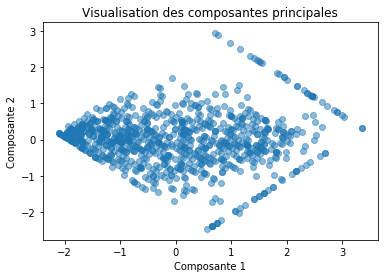

```python
# Les aléas sont clairement aprés l'APC
fig = plt.figure()
plt.scatter(comp1, comp2, alpha=0.5)
plt.title('Visualisation des composantes principales')
plt.xlabel('Composante 1')
plt.ylabel('Composante 2')
plt.show()
fig.savefig('ComposantesPrincipales2AEnLecEtMath.png')
```

```python
# quantité  de  variance expliquée par composante
model_apc.explained_variance_
```

```
array([1.50351184, 0.49871038])
```

```python
# le pourcentage de variance expliquée par composante
model_apc.explained_variance_ratio_
```

```
array([0.75092156, 0.24907844])
```

```python
# pourcentage cumulé de la variance expliquée
model_apc.explained_variance_ratio_.cumsum()
```

```
array([0.75092156, 1.        ])
```

```python
# nombre de composante
model_apc.n_components_
```

```
2
```

```python
# Composante par axe
model_apc.components_
```

```
array([[-0.70710678, -0.70710678],
       [ 0.70710678, -0.70710678]])
```

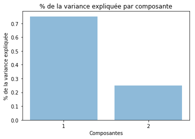

```python
# visualisation du pourcentage de la variance par composante
plt.bar(range(1, 1+model_apc.n_components_), model_apc.explained_variance_ratio_, alpha=0.5)
plt.title('% de la variance expliquée par composante')
plt.xlabel('Composantes')
plt.ylabel('% de la variance expliquée')
plt.xticks(range(1, 1+model_apc.n_components_))
plt.show()
```

# Exploration des données de la 5é année des écoles bilingues en Côte d'Ivoire

- Nombre d'observatons:**359**
- Nombre de variables :**285**
- Nombre d'eléve par école: **variable d'une école à l'autre, entre 63 et 11**

1. les enseignements-apprentissages?
2. ou l'adaptation des outils de collecte ?
3. ou la qualité de la collecte elle même ?

```python
df5.id_elev.nunique()
```

```
65
```

```python
df2.numeleve.nunique()
```

```
30
```

```python
df5.sample(5)
```

|  | livret | numadmin | numecole | id_elev | qe61 | qe62 | qe63 | qe64a | qe64b | qe64c | ... | Mat_m23 | Mat_m24 | Mat_m25 | Mat_m26 | Mat_m27 | Mat_m28 | Mat_m29 | Mat_m30 | S_FR5A100 | S_MTH5A100 |
| --- | --- | --- | --- | --- | --- | --- | --- | --- | --- | --- | --- | --- | --- | --- | --- | --- | --- | --- | --- | --- | --- |
| 297 | C | 9.0 | 8044 | 24 | 2010-02-19 00:00:00 | 11 | 2 | 2 | 1 | 2 | ... | 1 | 0 | 1 | 0 | 1 | 1 | 1 | 1 | 39.285713 | 90.000000 |
| 99 | A | 1.0 | 17669 | 9 | 2010-01-01 00:00:00 | 11 | 1 | 1 | 1 | 2 | ... | 0 | 0 | 0 | 0 | 0 | 0 | 0 | 0 | 42.857143 | 42.105263 |
| 216 | B | 3.0 | 17669 | 25 | 2008-01-01 00:00:00 | 13 | 2 | 1 | 1 | 1 | ... | 0 | 0 | 1 | 0 | 1 | 1 | 1 | 1 | 81.250000 | 60.000000 |
| 261 | C | 1.0 | 6217 | 31 | 2010-01-01 00:00:00 | 11 | 1 | 1 | 1 | 2 | ... | 1 | 0 | 0 | 0 | 0 | 0 | 1 | 0 | 50.000000 | 25.000000 |
| 242 | C | 8.0 | 5877 | 33 | 2007-01-01 00:00:00 | 14 | 1 | 1 | 1 | 2 | ... | 0 | 0 | 0 | 0 | 0 | 1 | 0 | 1 | 28.571428 | 45.000000 |

5 rows × 285 columns

```python
df5.shape
```

```
(359, 285)
```

```python
df5.columns
```

```
Index(['livret', 'numadmin', 'numecole', 'id_elev', 'qe61', 'qe62', 'qe63',
       'qe64a', 'qe64b', 'qe64c',
       ...
       'Mat_m23', 'Mat_m24', 'Mat_m25', 'Mat_m26', 'Mat_m27', 'Mat_m28',
       'Mat_m29', 'Mat_m30', 'S_FR5A100', 'S_MTH5A100'],
      dtype='object', length=285)
```

```python
# nombre d'eléves par école
df5['numecole'].value_counts()
```

```
17669    63
15915    54
5877     45
8191     42
6217     31
7603     30
7556     30
8044     28
7437     25
22430    11
Name: numecole, dtype: int64
```

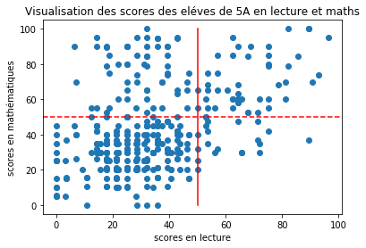

```python
fig = plt.figure()
plt.scatter(df5['S_FR5A100'], df5['S_MTH5A100'])
plt.title('Visualisation des scores des eléves de 5A en lecture et maths')
plt.xlabel('scores en lecture')
plt.ylabel('scores en mathématiques')

constant = 50
plt.axhline(constant, color='r', linestyle='--')
plt.plot([constant, constant], [0, 100], color='red')
#plt.plot([0, 100], [constant, constant], color='red')

plt.show()
fig.savefig('ScoresDesEleves5AEnLecEtMath.png')
```

```python
# Determinantion du coefficient de pearson

coef5, pval5 = pearsonr(df5['S_FR5A100'], df5['S_MTH5A100'])
print("la coefficient de correlation est égal à :", coef5)
print('avec une p_value égal à :', pval5)
```

```
la coefficient de correlation est égal à : 0.42287464852415196
avec une p_value égal à : 5.256164494918744e-17
```

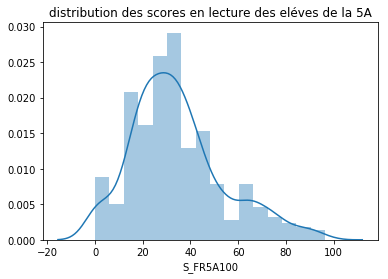

```python
sns.distplot(df5['S_FR5A100'])
plt.title("distribution des scores en lecture des eléves de la 5A")
```

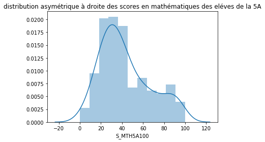

```python
sns.distplot(df5['S_MTH5A100'])
plt.title("distribution asymétrique à droite des scores en mathématiques des eléves de la 5A")
```

```
les valeurs extrémes identifiés sont celles des rares eléves ayant réaliser des trés bons scores en lectures (graphique de gauche)
Globalement les scores sont faibles avec une tendance meilleure en mathématique qu'en lecture
AxesSubplot(0.125,0.125;0.775x0.755)
```

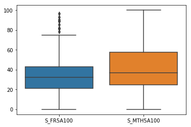

```python
print("les valeurs extrémes identifiés sont celles des rares eléves ayant réaliser des trés bons scores en lectures (graphique de gauche)")
print("Globalement les scores sont faibles avec une tendance meilleure en mathématique qu'en lecture")
print(sns.boxplot(data=df5[['S_FR5A100', 'S_MTH5A100']]))
```